# Overview of Healthcare Access, Expenditure, and Coverage in the US

The NHIS is the nation’s largest in-person household health survey. It has been conducted annually since 1957 by the National Center for Health Statistics (NCHS), which is a part of the Centers for Disease Control and Prevention (CDC). Interviewing is done by the U.S. Census Bureau’s field staff. During face-to-face interviews, participants provided sociodemographic data and information about health insurance coverage status.

The purpose of our research project is to explore health insurance coverage using the **National Health Interview Survey (NHIS)** data. A broad range of topics are covered within the dataset, but we will specifically focus on **healthcare access, coverage, and expenditure** across a multitude of factors such as over time and educational attainment. We explore three specific questions:

1. **Access**: Does higher educational attainment cause greater chance of acquiring medical insurance?
2. **Coverage**: What percentage of the population had health coverage?
3. **Expenditure**: How has the amount of money spent for medical care changed over the years?

### Healthcare Expenditure

#### "How has the amount of money spent for medical care changed over the years?"

The NHIS survey contained various information on healthcare expenditure, such as the premiums they pay for all the individual health care plans they currently had. One specific question asked respondents the total amount of money spent for medical care, for the past year. This independent variable only provides a rough estimate on the family's expenditure on medical care, but is still relevant since interviewers directed respondents to exclude the insurance premiums, over-the-counter drugs, and any costs for which they expected to be reimbursed. A distribution of this can be seen below:

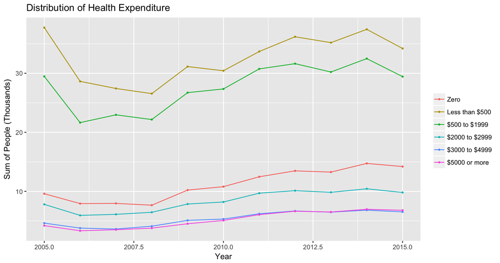

Right off the bat we could see that for the most part, respondents are spending less than $500 only for health insurance, which fluctuates between 25,000 to 40,000 people every year. The next biggest group would be the people spending $500 to $1999, fluctuating between 20,000 to 33,000 people every year.

Of course, this is just an estimate, but a statistical inference can be made on the greater population, by using survey weights provided within the NHIS dataset. A **stratified random sampling** was implemented to calculate our weighted proportions of health expenditure. The results can be seen below:

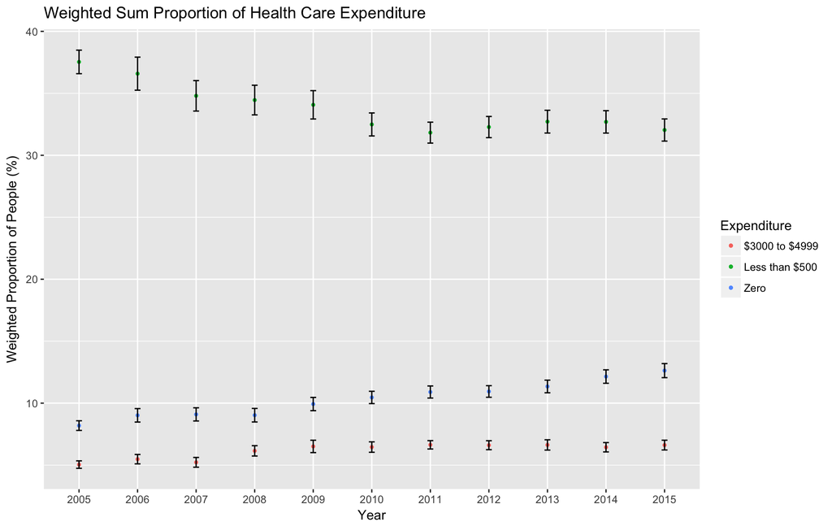

We see that the largest proportion of people mostly spent less than 500 dollars through out time, with atleast more than 30% given any year. Specifically, for 2005, 37.5% percent of the population spent less than 500 dollars, but for 2015, it went down to 32.04%. For the people spending no money on health insurance, this proportion mostly stayed between 8% to 12% over the years, with a positive increase over time. One would expect that with the introduction of the Affordable Care Act in 2010, which promised [reducing health care costs to make it more affordable](https://time.com/money/4503325/obama-health-care-costs-obamacare/), the amount of money people are spending on health care would **decrease**. These expectations turned out to be true, since the graph reflects a positive rate of change for people spending no money on health insurance, and negative rate of change for people spending less than 500 dollars.

### Healthcare Access

#### "Does higher educational attainment cause greater chance of acquiring medical insurance?"

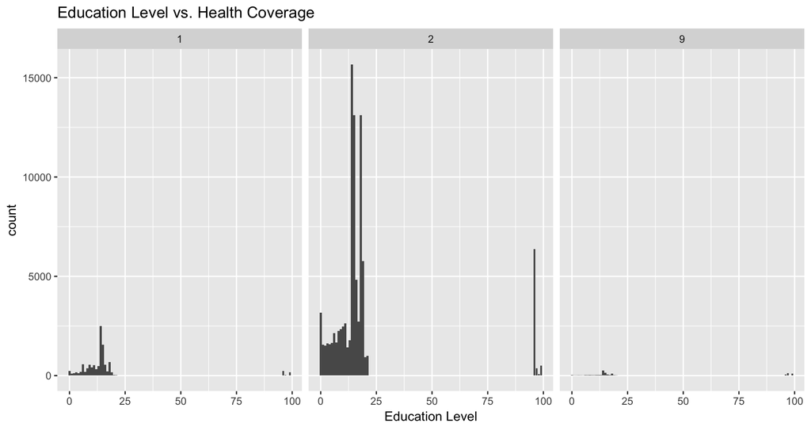

The first graph that we see here represents whether or not an individual obtained health coverage based on their education level. Immediately, we see that the number 2 subgraph contains a lot more results than the number 1 subgraph, which indicates that there were more people who received health coverage than did not. Under the number 1 subgraph, we see the varying number of people who did not receive health coverage given their level of education. There appears to be a notable peak at the number 14 which is indicative of those who have completed up to a high school diploma. A second notable peak is at the number 15 which represents those who have attended college but had not received a degree. Such might be the case because most people finish school up until high school and also attend college, so it would make sense that the bulk of the sample surveyed would reside in that educational attainment categories. It would furthermore make sense that they did not receive health coverage because nowadays, people obtain health/medical insurance from their workplaces since getting these plans on an individual basis is a lot more expensive. Those who did not finish college or only obtained a high school diploma might have not been able to get the best occupation due to their lack of education and skills in the workforce, which affected their ability to get health coverage from their employer.

In the number 2 subgraph, we see three notable peaks--one at the x-coordinate values 14, 15, and 18. These peaks correspond to the bulk of those who received health/medical insurance given that they either graduated high school, went to college but did not get a degree, or got a Bachelor’s degree. What is interesting about this is that there were a lot of people who did not AND did get health coverage given that they graduated from high school or went to college but did not get a degree. This might reveal to us that even with a high school degree it is possible to get a steady job that includes medical/health insurance coverage. However, analyzing the data further, it makes sense that a lot of people who received health coverage received at least a Bachelor’s degree, because that level of education makes it a lot easier to get jobs that pay well and include a lot of benefits such as medical insurance.

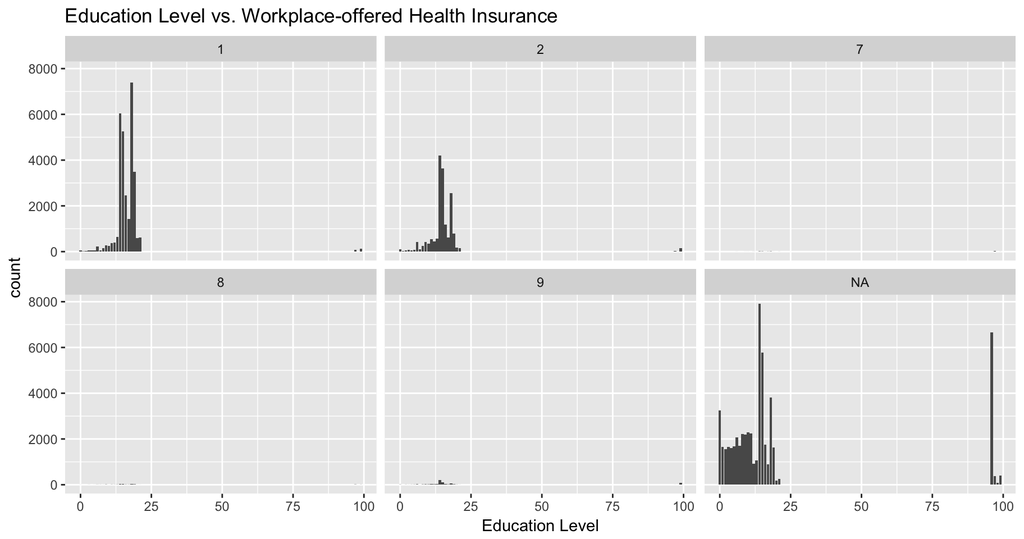

The second graph we are looking at compares educational attainment with whether or not a person received health insurance from their workplace. The number 1 subgraph represents the count of people who did receive health insurance at their workplace given their highest level of educational attainment, while number 2 subgraph represents the count of people who did not receive health insurance at work given their highest level of educational attainment. Again, in both graphs, x-coordinate values 14, 15, and 18, corresponding to having graduated high school, attending college without getting a degree, and getting a bachelor’s degree respectively, are the most prominent peaks in the graph. This is due to the fact that most people finish at least up until high school, attend college at some point and realize that it wasn’t for them, or obtain their bachelor’s degree. Very few people quit grade school in the middle of it and very few people get a higher education such as a master’s or doctoral degree, which is why the sample count is so low at those other values. Based on the number 1 subgraph however, we see that the most people who got health insurance from their workplace are those who graduated with a Bachelor’s degree. This reveals the importance of obtaining a Bachelor’s degree when getting a job. Other interesting points of analysis are that more high school graduates received workplace-offered health insurance than those who attended college but did not get a degree. One reasoning behind this is that those who did not receive a degree from college might have been those who quit in order to pursue their own businesses, and therefore did not work for an existing corporation that would have otherwise offered them health insurance. The number 2 subgraph shows that high school graduates were the least likely to receive health insurance from their workplace, which again points back to the fact that they probably weren’t able to get a great enough job that offered them benefits such as health insurance. Most decent jobs nowadays require people to have at least a bachelor’s degree. The lowest of the three peaks, though, are those who got a bachelor’s degree, and it shows that with a higher level of education, you will have a better chance of getting a job with better benefits.

### Healthcare Coverage

#### "What percentage of the population had health insurance coverage?"

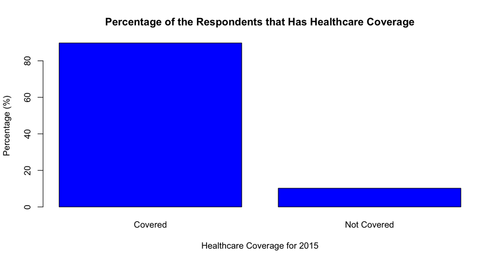

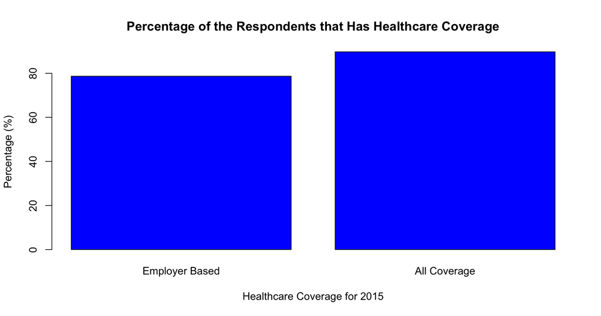

A huge discussions these recent weeks has been Obama care. Some view it was a total disaster while others suggest that it works but it is not perfect. Our president has spoken that this plan is terrible and this inspired us to consider the what a reality would be like if there was no more Obama care. As a group we believed that without government help, individuals would have to resort to other sorts of health care plans. We decided to focus on employers to study if there is any significant correlation between employers and health care coverage. We do have to note that this information lacked the participation from 42728 individuals. This number was subtracted from the group that did responded as we were interested in the population that did have some sort of coverage.

In respects to the National Health Interview Survey, we wanted to research what percentage of the population had healthcare coverage. We used the “NOTCOV” column of the survey to retrieve the amount of individuals that had coverage and those who did not have healthcare coverage. We do want to mention that there was a total of 1102 individual that responded with “Don’t know”. WE made the decision to exclude these individuals from our data since they do not represent your targeted population.  
When comparing just the proportions of those who had healthcare coverage to those who lacked coverage, there was a clear transformation. Only 10.23% of the individuals that participated in this survey did not have healthcare coverage. While 89.76% of these individuals did have coverage.

##### Health Care Coverage over Time

We also looked at the health insurance coverage status over the years to see if there was any significant point on time in which healthcare coverage increased or decreased. The following visualization displays a high level overview of the percentage of people who **didn't** have any health insurance. According to the [codebook](https://www.cdc.gov/nchs/nhis/nhis_questionnaires.htm), uninsured individuals include:

> "Those without any private insurance, or without public health insurance coverage through Medicaid, Medicare, military health care (1976 forward), Children's Health Insurance Program (CHIP) (1999 forward), or a state-sponsored or other government program (1997 forward). Persons covered only by a private plan that paid for one type of service, such as accidents or dental care, are also considered uninsured. Persons covered only by the Indian Health Service (1993 forward) are coded as having no health insurance. "

Data Preparation

To explore the question above, we looked at data from the 05' to 15' NHIS surveys, downloaded from [this](https://ihis.ipums.org/ihis/) website. Using a stratified random sample, we counted the weighted total of the population who responded "No" to having any health insurance coverage. We then compared this to to the weighted population for that respective year, ultimately getting a weighted proportion of people that respective year who didn't have health insurance, accompanied by a confidence interval.  
Along with the graph, we provide some [healthcare reforms](https://resources.ehealthinsurance.com/affordable-care-act/history-timeline-affordable-care-act-aca) that were introduced during the focused timeframe, in order to provide a better [historical context](https://kaiserfamilyfoundation.files.wordpress.com/2011/03/5-02-13-history-of-health-reform.pdf), which could possibly explain the numbers behind the graph.

Year 2005

We start our analysis by looking at health care coverage for the year 2005. There was no particular reason we started with 2005, The NHIS survey containshealth care coverage information dating all the way to 1990s.

- **Deficit Reduction Act of 2005** is introduced
- Mainly aimed to "provides States with much of the flexibility they have been seeking over the years to make significant reforms to their Medicaid Programs." - [Source](https://www.cms.gov/Regulations-and-Guidance/Legislation/DeficitReductionAct/downloads/checklist1.pdf)
- Average percent of population with no health insurance is 14.4% (CI: 13.89% , 14.90%)

Pre ACA: Year 2005-2010

Looking at health insurance coverage alone, overall, there seems to be an upward trend of proportion of people who doesn't have healthcare. The proportion of people without health care coverage **increased** from 2005(M= 14.4%, CI: [13.89% , 14.90%]) to 2010 (M= 15.88%, CI = [15.28%, 16.48%]).

- **July 2009**: Speaker of the House Nancy Pelosi and a group of Democrats from the House of Representatives reveal their plan for overhauling the health-care system. It’s called H.R. 3962, the Affordable Health Care for America Act.
- **July 1, 2010**: Pre-Existing Condition Insurance Plan (PCIP): This program is designed to make health insurance available to those that have been denied coverage by private insurance companies because of a pre-existing condition.
- **March 23, 2010**: President Obama signs the Patient Protection and Affordable Care Act into law.

Post ACA: Year 2011-2015

From 2011 to 2015, now we see a **negative** slope in change of percent of population who didn't have health insurance, from 2010 (M= 15.88%, CI = [15.28%, 16.48%]) to 2015 (M= 9.07%, CI = [8.70%, 9.43%])

- **January 2011**: A Florida judge rules that elements of the Affordable Care Act are unconstitutional.
- **November 6, 2012**: President Obama is re-elected, effectively ensuring the ACA will survive.
- **July 2, 2013**: The White House agrees to a one-year delay for large businesses to provide workers with affordable health care.
- **January 2014**: Requirement to buy health insurance: To prevent people from waiting until they get sick to buy health insurance, the ACA requires all Americans to buy health insurance or pay a fine. The fine starts at $95 for an individual in 2014 and goes up each year until 2016, when the fine is the largest of the following two:$695 or 2.5% of a person’s annual income.
- **January 2014**: No restrictions on pre-existing conditions: Insurance companies are required to provide health insurance to any adult aged 19 to 64 who applies for coverage.

[interactive chart not shown]